# chapter6

### Standardizing the data

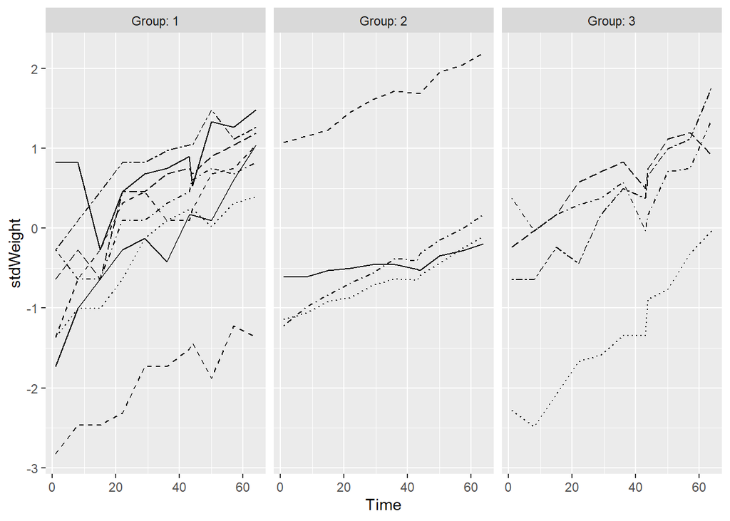

```r
# Standardise the variable weight
RATSL <- RATSL %>%
  group_by(Group) %>%
  mutate(stdWeight = c(scale(Weight))) %>%
  ungroup()

# Plot again with the standardised data
ggplot(RATSL, aes(x = Time, y = stdWeight, linetype = ID)) +
  geom_line() +
  scale_linetype_manual(values = rep(1:10, times=4)) +
  facet_grid(. ~ Group, labeller = label_both) +
  theme(legend.position = "none") +
  scale_y_continuous(limits = c(min(RATSL$stdWeight), max(RATSL$stdWeight)))
```

After being standardized, the weight difference between the groups are not as pronounced anymore. Now, we can see the changes that happen in each group more clearly. Although it is still unclear if there are any differences between each group, lighter rats in all groups seem to have the most extreme weight gain compared to heavier rats in its group.

### Summary graph

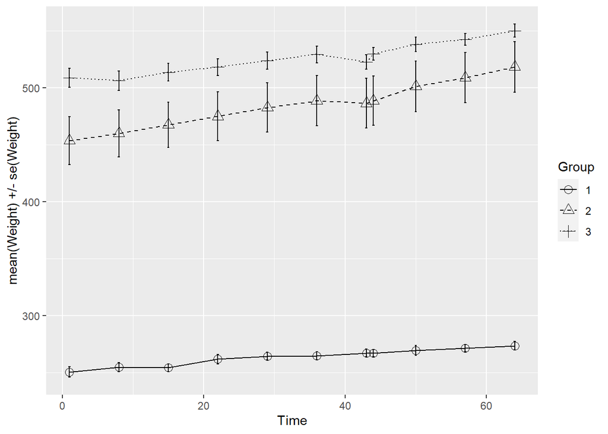

```r
# Number of Time
n <- RATSL$Time %>% unique() %>% length()

# Summary data with mean and standard error of Weight by treatment and week
RATSS <- RATSL %>%
  group_by(Group, Time) %>%
  summarise( mean = mean(Weight), se = sd(Weight)/sqrt(n) ) %>%
  ungroup()

# Plot the mean profiles
ggplot(RATSS, aes(x = Time, y = mean, linetype = Group, shape = Group)) +
  geom_line() +
  scale_linetype_manual(values = c(1,2,3)) +
  geom_point(size=3) +
  scale_shape_manual(values = c(1,2,3)) +
  geom_errorbar(aes(ymin = mean - se, ymax = mean + se, linetype="1"), width=0.3) +
  scale_y_continuous(name = "mean(Weight) +/- se(Weight)")
```

The plot above shows the average increase of weight over time in each group of rats. The second group seem to have the most pronounced increase of average weight gain compared to the other two groups, and Group 1 seem to have the lowest increase.

### Checking for outliers

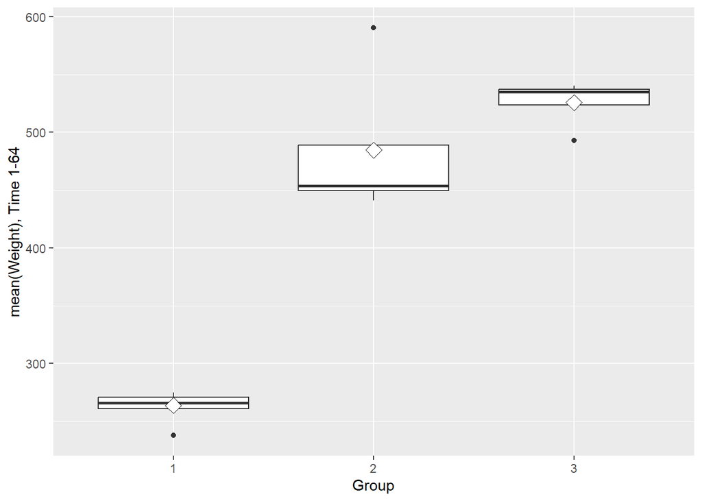

```r
# Create a summary data by treatment and subject with mean as the summary variable (ignoring baseline week 0).
RATSL8S <- RATSL %>%
  filter(Time > 0) %>%
  group_by(Group, ID) %>%
  summarise( mean=mean(Weight) ) %>%
  ungroup()

# Draw a boxplot of the mean versus treatment
ggplot(RATSL8S, aes(x = Group, y = mean)) +
  geom_boxplot() +
  stat_summary(fun.y = "mean", geom = "point", shape=23, size=4, fill = "white") +
  scale_y_continuous(name = "mean(Weight), Time 1-64")
```

Each group has an outlier. Both Group 1 and Group 3 has an extreme low point, while Group 2 has an extreme high point. We can check from the data to find the outliers in each group. It also seems that the distribution of the second and third groups are quite skewed. Next, we will remove the outliers.

### Removing the outliers

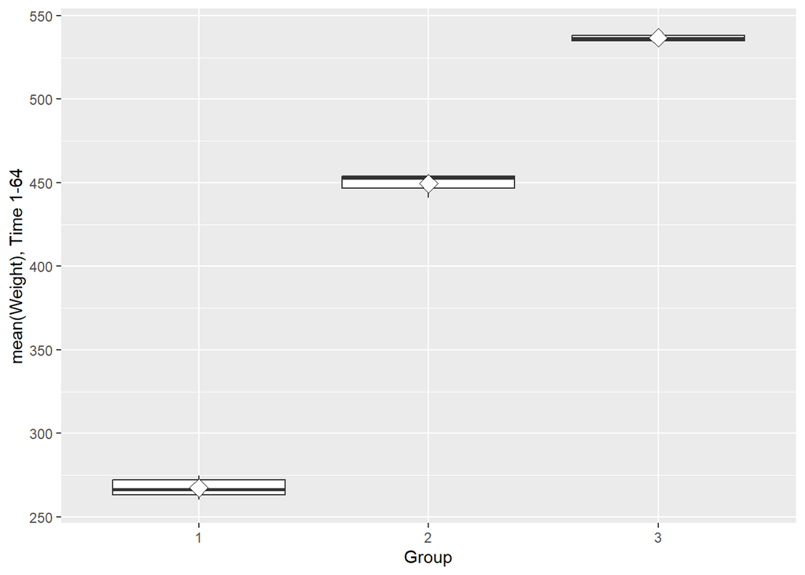

```r
# Create a new data by filtering the outlier and adjust the ggplot code the draw the plot again with the new data
RATSL8S1 <- filter(RATSL8S, (Group==1 & mean>250) | (Group==2 & mean < 590) | (Group==3 & mean>500))

# Draw a boxplot of the filtered data
ggplot(RATSL8S1, aes(x = Group, y = mean)) +
  geom_boxplot() +
  stat_summary(fun.y = "mean", geom = "point", shape=23, size=4, fill = "white") +
  scale_y_continuous(name = "mean(Weight), Time 1-64")
```

After removing the outliers, the distribution of each group changed. This change is more apparent in the second and third group. The range of the quantiles seem to decrease quite significantly, and the skew of the distribution seem to have lessened.

### Statistical testing

We will not do a two-sample t-test as there are more than 2 groups in this data.

```r
# Add the baseline from the original data as a new variable to the summary data
RATSL8S2 <- RATSL8S %>%
  mutate(baseline = RATS$WD1)

# Fit the linear model with the mean as the response
fit <- lm(mean~ baseline + Group, data = RATSL8S2)

# Compute the analysis of variance table for the fitted model with anova()
anova(fit)
```

```
## Analysis of Variance Table
##
## Response: mean
##           Df Sum Sq Mean Sq   F value    Pr(>F)
## baseline   1 252125  252125 2237.0655 5.217e-15 ***
## Group      2    726     363    3.2219   0.07586 .
## Residuals 12   1352     113
## ---
## Signif. codes:  0 '***' 0.001 '**' 0.01 '*' 0.05 '.' 0.1 ' ' 1
```

The baseline is significant, which means that the original weight of the rats do affect the weight increase. On the other hand, Group is significant at 0.1 level, which means that we found a weak evidence that the diet difference affects the weight increase in rats.

## BPRS data

### Exploring the data

```r
# loading the original data
BPRS <- read.table("https://raw.githubusercontent.com/KimmoVehkalahti/MABS/master/Examples/data/BPRS.txt", sep =" ", header = T)

# loading the wrangled data set
BPRSL <- read.csv(file = "bprsl.csv", sep=",", header=TRUE)

# Look at the (column) names
names(BPRSL)
```

```
## [1] "treatment" "subject"   "weeks"     "bprs"      "week"
```

```r
# Look at the structure
str(BPRSL)
```

```
## 'data.frame':    360 obs. of  5 variables:
##  $ treatment: int  1 1 1 1 1 1 1 1 1 1 ...
##  $ subject  : int  1 2 3 4 5 6 7 8 9 10 ...
##  $ weeks    : chr  "week0" "week0" "week0" "week0" ...
##  $ bprs     : int  42 58 54 55 72 48 71 30 41 57 ...
##  $ week     : int  0 0 0 0 0 0 0 0 0 0 ...
```

```r
# Print out summaries of the variables
summary(BPRSL)
```

```
##    treatment      subject         weeks                bprs            week
##  Min.   :1.0   Min.   : 1.00   Length:360         Min.   :18.00   Min.   :0
##  1st Qu.:1.0   1st Qu.: 5.75   Class :character   1st Qu.:27.00   1st Qu.:2
##  Median :1.5   Median :10.50   Mode  :character   Median :35.00   Median :4
##  Mean   :1.5   Mean   :10.50                      Mean   :37.66   Mean   :4
##  3rd Qu.:2.0   3rd Qu.:15.25                      3rd Qu.:43.00   3rd Qu.:6
##  Max.   :2.0   Max.   :20.00                      Max.   :95.00   Max.   :8
```

This data was obtained from 40 male subjects who were randomly assigned into 2 treatment groups. The subjects were then rated on the brief psychriatric rating scale (BPRS) which access various symptoms such as hostility, suspiciousness, and hallucination. The measurement was done before the treatment (week 0) and then weekly for eight weeks.

The wrangled long form data contains 360 rows in total and 5 variables which are:

| Variable | Description |
| --- | --- |
| treatment | Treatment group of each subject (integer, 1 or 2) |
| subject | ID of each subject in each group (integer, 1-20) |
| weeks | Measurement week (character, 9 different entries) |
| bprs | BPRS score (integer) |
| week | Measurement week (integer, 0-8) |

### Factor the categorical variables

```r
# turn into factors
BPRSL$treatment <- factor(BPRSL$treatment)
BPRSL$subject <- factor(BPRSL$subject)

# the data is already converted to the long form in the wrangling exercise

# checking
glimpse(BPRSL)
```

```
## Rows: 360
## Columns: 5
## $ treatment <fct> 1, 1, 1, 1, 1, 1, 1, 1, 1, 1, 1, 1, 1, 1, 1, 1, 1, 1, 1, 1, …
## $ subject   <fct> 1, 2, 3, 4, 5, 6, 7, 8, 9, 10, 11, 12, 13, 14, 15, 16, 17, 1…
## $ weeks     <chr> "week0", "week0", "week0", "week0", "week0", "week0", "week0…
## $ bprs      <int> 42, 58, 54, 55, 72, 48, 71, 30, 41, 57, 30, 55, 36, 38, 66, …
## $ week      <int> 0, 0, 0, 0, 0, 0, 0, 0, 0, 0, 0, 0, 0, 0, 0, 0, 0, 0, 0, 0, …
```

The categorical variables had been successfully converted into factors.

### Plotting

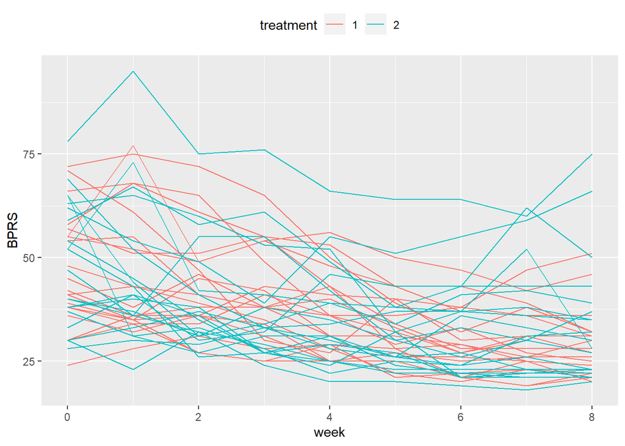

```r
#mutating the subject variable for easier plotting
BPRSL$subject <- as.numeric(BPRSL$subject)
BPRSL <- mutate(BPRSL, subject = ifelse(treatment == "2", subject+20, subject))
BPRSL$subject <- factor(BPRSL$subject)

#plot
ggplot(BPRSL, aes(x = week, y = bprs, group = subject)) +
  geom_line(aes(col = treatment))+ #changed linetype to col because it is easier to differentiate the groups with color
  scale_y_continuous(name = "BPRS")+
  theme(legend.position = "top")
```

In general, it seems that BPRS values decreases over time in general. However, it is not clear yet if there are any differences between the groups. The data in the second treatment group (blue) seem to have a wider range/variation compared to the first group.

### Create a regression model

```r
# create a regression model RATS_reg
BPRS_reg <- lm(bprs~ week+treatment, data=BPRSL)

# print out a summary of the model
summary(BPRS_reg)
```

```
##
## Call:
## lm(formula = bprs ~ week + treatment, data = BPRSL)
##
## Residuals:
##     Min      1Q  Median      3Q     Max
## -22.454  -8.965  -3.196   7.002  50.244
##
## Coefficients:
##             Estimate Std. Error t value Pr(>|t|)
## (Intercept)  46.4539     1.3670  33.982   <2e-16 ***
## week         -2.2704     0.2524  -8.995   <2e-16 ***
## treatment2    0.5722     1.3034   0.439    0.661
## ---
## Signif. codes:  0 '***' 0.001 '**' 0.01 '*' 0.05 '.' 0.1 ' ' 1
##
## Residual standard error: 12.37 on 357 degrees of freedom
## Multiple R-squared:  0.1851, Adjusted R-squared:  0.1806
## F-statistic: 40.55 on 2 and 357 DF,  p-value: < 2.2e-16
```

The variable week is significant with a negative estimate, supporting the observation that BPRS score tend to decrease in time. However, the treatment variable is not found to be significant, which means that we did not find any evidence that the two treatments affects the BPRS score differently. It seems that the two treatments have a similar degree of impact to the BPRS score. We should note that this model ignores the independence assumption.

### Random intercept model

```r
# access library lme4
library(lme4)

# Create a random intercept model
BPRS_ref <- lmer(bprs ~ week + treatment + (1 | subject), data = BPRSL, REML = FALSE)

# Print the summary of the model
summary(BPRS_ref)
```

```
## Linear mixed model fit by maximum likelihood  ['lmerMod']
## Formula: bprs ~ week + treatment + (1 | subject)
##    Data: BPRSL
##
##      AIC      BIC   logLik deviance df.resid
##   2582.9   2602.3  -1286.5   2572.9      355
##
## Scaled residuals:
##      Min       1Q   Median       3Q      Max
## -2.27506 -0.59909 -0.06104  0.44226  3.15835
##
## Random effects:
##  Groups   Name        Variance Std.Dev.
##  subject  (Intercept) 97.39    9.869
##  Residual             54.23    7.364
## Number of obs: 360, groups:  subject, 40
##
## Fixed effects:
##             Estimate Std. Error t value
## (Intercept)  46.4539     2.3521  19.750
## week         -2.2704     0.1503 -15.104
## treatment2    0.5722     3.2159   0.178
##
## Correlation of Fixed Effects:
##            (Intr) week
## week       -0.256
## treatment2 -0.684  0.000
```

This model allows the linear regression fit for each subject to differ in *intercept* from other subjects. The estimated standard deviation for subject in this model is quite large, which means that there are considerable differences in the intercept of each subject. Meanwhile, the estimates for the predictor variables are similar to the previous model.

### Random intercept and random slope model

```r
# create a random intercept and random slope model
BPRS_ref1 <- lmer(bprs ~ week + treatment + (week | subject), data = BPRSL, REML = FALSE)

# print a summary of the model
summary(BPRS_ref1)
```

```
## Linear mixed model fit by maximum likelihood  ['lmerMod']
## Formula: bprs ~ week + treatment + (week | subject)
##    Data: BPRSL
##
##      AIC      BIC   logLik deviance df.resid
##   2523.2   2550.4  -1254.6   2509.2      353
##
## Scaled residuals:
##     Min      1Q  Median      3Q     Max
## -2.4655 -0.5150 -0.0920  0.4347  3.7353
##
## Random effects:
##  Groups   Name        Variance Std.Dev. Corr
##  subject  (Intercept) 167.827  12.955
##           week          2.331   1.527   -0.67
##  Residual              36.747   6.062
## Number of obs: 360, groups:  subject, 40
##
## Fixed effects:
##             Estimate Std. Error t value
## (Intercept)  45.9830     2.6470  17.372
## week         -2.2704     0.2713  -8.370
## treatment2    1.5139     3.1392   0.482
##
## Correlation of Fixed Effects:
##            (Intr) week
## week       -0.545
## treatment2 -0.593  0.000
```

This model allows the linear regression fits for each subject to differ in both intercept and slope. This way, the differences in each subject’s growth profiles and the effect of time can be both accounted for. In this model, the estimate for week is still similar, but the estimate for treatment is quite different. It seems that the difference of the treatment group is more apparent in this model compared to the previous ones.

### Anova test

```r
# perform an ANOVA test on the two models
anova(BPRS_ref1, BPRS_ref)
```

```
## Data: BPRSL
## Models:
## BPRS_ref: bprs ~ week + treatment + (1 | subject)
## BPRS_ref1: bprs ~ week + treatment + (week | subject)
##           npar    AIC    BIC  logLik deviance  Chisq Df Pr(>Chisq)
## BPRS_ref     5 2582.9 2602.3 -1286.5   2572.9
## BPRS_ref1    7 2523.2 2550.4 -1254.6   2509.2 63.663  2  1.499e-14 ***
## ---
## Signif. codes:  0 '***' 0.001 '**' 0.01 '*' 0.05 '.' 0.1 ' ' 1
```

The likelihood ratio test between the two models gives a chi square statistics of 63.663, and the associated p-value is very small. This means that the random intercept and slope model provides a better fit to the data.

### Interaction

```r
# create a random intercept and random slope model with the interaction
BPRS_ref2 <- lmer(bprs ~ week + treatment + week*treatment + (week | subject), data = BPRSL, REML = FALSE)

# print a summary of the model
summary(BPRS_ref2)
```

```
## Linear mixed model fit by maximum likelihood  ['lmerMod']
## Formula: bprs ~ week + treatment + week * treatment + (week | subject)
##    Data: BPRSL
##
##      AIC      BIC   logLik deviance df.resid
##   2523.5   2554.5  -1253.7   2507.5      352
##
## Scaled residuals:
##     Min      1Q  Median      3Q     Max
## -2.4747 -0.5256 -0.0866  0.4435  3.7884
##
## Random effects:
##  Groups   Name        Variance Std.Dev. Corr
##  subject  (Intercept) 164.204  12.814
##           week          2.203   1.484   -0.66
##  Residual              36.748   6.062
## Number of obs: 360, groups:  subject, 40
##
## Fixed effects:
##                 Estimate Std. Error t value
## (Intercept)      47.8856     2.9840  16.047
## week             -2.6283     0.3752  -7.006
## treatment2       -2.2911     4.2200  -0.543
## week:treatment2   0.7158     0.5306   1.349
##
## Correlation of Fixed Effects:
##             (Intr) week   trtmn2
## week        -0.668
## treatment2  -0.707  0.473
## wek:trtmnt2  0.473 -0.707 -0.668
```

```r
# perform an ANOVA test on the two models
anova(BPRS_ref2, BPRS_ref1)
```

```
## Data: BPRSL
## Models:
## BPRS_ref1: bprs ~ week + treatment + (week | subject)
## BPRS_ref2: bprs ~ week + treatment + week * treatment + (week | subject)
##           npar    AIC    BIC  logLik deviance Chisq Df Pr(>Chisq)
## BPRS_ref1    7 2523.2 2550.4 -1254.6   2509.2
## BPRS_ref2    8 2523.5 2554.6 -1253.7   2507.5  1.78  1     0.1821
```

### Plotting the fitted values

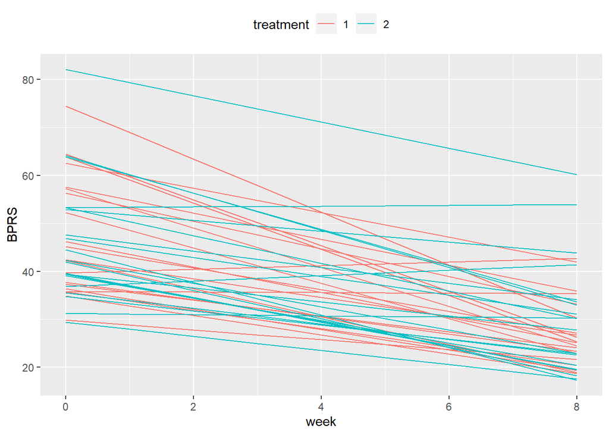

```r
# Create a vector of the fitted values
Fitted <- fitted(BPRS_ref1)

# Create a new column fitted
BPRSL <- BPRSL %>%
  mutate(Fitted)

# draw the plot with the fitted values
ggplot(BPRSL, aes(x = week, y = Fitted, group = subject)) +
  geom_line(aes(col = treatment))+
  scale_y_continuous(name = "BPRS")+
  theme(legend.position = "top")
```

This plot shows the fitted value for each subject according to the best fit model (random slope random intercept without interaction). We can see that in general, the BPRS score is decreasing for most of the subjects in both treatment groups, which may indicate that both treatment works in reducing BPRS score. However, we did not find enough evidence that the effect of two treatments differs.